# Featurization, Model Selection & Tuning Project - Divya Dhaipullay

```python
import time
from math import sqrt
import numpy as np
import pandas as pd
import seaborn as sns
import warnings
warnings.filterwarnings('ignore')
from scipy.stats import zscore
import statsmodels.api as sm
from statsmodels.formula.api import ols
import matplotlib.pyplot as plt
%matplotlib inline
from scipy import stats
from sklearn.preprocessing import StandardScaler
from sklearn.preprocessing import LabelEncoder
from sklearn.model_selection import train_test_split
from sklearn.preprocessing import minmax_scale
from sklearn.linear_model import LogisticRegression
from sklearn.naive_bayes import GaussianNB
from sklearn.neighbors import KNeighborsClassifier
from sklearn.svm import SVC
from sklearn.ensemble import RandomForestClassifier
from xgboost import XGBClassifier
from sklearn.model_selection import RandomizedSearchCV, GridSearchCV,cross_validate
from sklearn.model_selection import KFold, StratifiedKFold, ShuffleSplit, LeavePOut, LeaveOneOut
from sklearn.model_selection import cross_val_score
from sklearn.tree import DecisionTreeClassifier
from sklearn.ensemble import RandomForestClassifier
from xgboost import XGBClassifier
from sklearn.ensemble import BaggingClassifier
from sklearn.ensemble import AdaBoostClassifier
from sklearn.ensemble import GradientBoostingClassifier
from sklearn.metrics import accuracy_score, recall_score, precision_score, confusion_matrix, classification_report, plot_confusion_matrix
from imblearn.over_sampling import SMOTE

from IPython.core.interactiveshell import InteractiveShell
InteractiveShell.ast_node_interactivity = "all"
```

```python
"""
:param file - path of the file

This method takes in path of the file as input and outputs the csv file as a dataFrame.

"""
def read_csv(file):
    return pd.read_csv(file)
"""
:param df - dataFrame

This method takes the dataFrame as input and print the data info
    - dataFrame shape,
    - no.of columns and rows
    - column names
    - categorical columns
    - non-categorical columns.

"""
def explore_data(df):
    df_shape = df.shape
    df_cols = df.columns
    df_cat_cols = np.asarray(df.select_dtypes('object').columns)
    df_num_cols = np.asarray(df.select_dtypes('number').columns)
    print('\n 'f'The Shape of Dataset: {df_shape} ; Number of Rows in the Dataset: {df_shape[0]} ; Number of Columns in the Dataset: {df_shape[1]}')
    print('\n 'f' The Columns of the Dataset are: {df_cols}')
    print('\n The Features of the Dataset are: \n', df.dtypes)
    print('\n 'f'The Non-Categorical Features of the Dataset are: {df_num_cols}')
    print('\n 'f'The Categorical Features of the Dataset are:{df_cat_cols} \n')
```

```python
"""
:param df - dataFrame

This method takes the dataFrame as teh input to handle the missingand null values

If the missing or null values percentage is lower than 10% of the entire data,
drop those rows containig or we impute the missing values using `mode_`

"""
def handling_missing_values(df, threshold):
    columns_to_drop = []
    print('\n The Null Values : \n')
    null_val = np.asarray(df.isnull().sum())
    print(df.isnull().sum(), "\n")
    perc_miss = df.isnull().sum() * 100 / len(df)
    missing_value_df = pd.DataFrame({'The percentage of missing values is': perc_miss})
    print('The Dataframe of Percentage of Missing Values :\n', missing_value_df)
    for i in df.columns:
        print('Column : ', i, '; Missing Percentage : ', perc_miss[i])
        if perc_miss[i] > 0 :
            if perc_miss[i] > threshold:
                columns_to_drop.append(i)
            else:
                mean = df[i].mean()
                df[i].fillna(mean, inplace=True)
    print('The Columns that are being Dropped', columns_to_drop)
    df.drop(columns_to_drop, axis=1, inplace=True)
    print(' The Missing values have been treated')
    return df

"""
:param df - dataFrame

This method takes the dataFrame as the input and handles the duplicate entries by dropping them

"""
def handling_duplicates(df):
    dup = df.duplicated()
    if sum(dup) > 0:
        df.drop_duplicates(inplace=True)
    print('The Duplicates have been Handled \n')
    print('---------------------------------')
    print('The Modified Data now looks like')
    return df

"""
:param df - dataFrame

This method outputs all the unique values of every column present in the dataset.

"""
def unique_val(df):
    for i in np.asarray(df.columns):
        print('\n'f'The Unique values in the Column {i} : is')
        print(df[i].unique())
```

```python
"""
:param df - dataFrame

This method eliminates those columns that have same/constant data for all rows in dataFrame.

"""
def eliminate_constant_valued_features(df):
      for i in np.asarray(df.columns):
        if df[i].nunique() == 1:
          print(f'dropping {i} cause it just have value : {df[i].unique()}')
          df.drop([i], axis=1, inplace=True)
      print('')
      return df
```

```python
"""
:param df - dataFrame

This method plots simple pair plot for the dataFrame.

"""
def graphs(df):
    target = np.asarray(df.columns)[-1]
    sns.pairplot(df);
    sns.pairplot(df,hue= target)

"""
:param df - dataFrame

This method checks for the correlation in the data.
If there are any high correlated columns (correlation > 0.85) - it handles by droppping the high correlated info

it returns the updated dataFrame

"""
def handling_extreme_corr(df):
    corr = df.corr().abs()
    print('\n Correlated Matrix \n', corr )
    upper_ = corr.where(np.triu(np.ones(corr.shape),k=1).astype(np.bool))
    print(upper_)
    drop_ = [col for col in upper_.columns if any(upper_[col] > 0.85)]
    print('\n Dropped Extreme Correlation ', drop_)
    print('\n' f' High Correlated Total Columns {len(drop_)} ', drop_)
    df1 = df.drop(np.asarray(drop_), axis=1)
    #df1 = df.drop(df.columns[drop_], axis=1)
    return df1
```

```python
"""
:param df - dataFrame
: threshold - max allowed correlation value

This method checks for the correlation in the data and returns the columns that have corr more than the given threshold.

"""
def fetch_correlated_columns(df, threshold):
    cor_matrix = df.corr().abs()
    upper_tri = cor_matrix.where(np.triu(np.ones(cor_matrix.shape),k=1).astype(np.bool))
    corr_cols =  [column for column in upper_tri.columns if any(upper_tri[column] > threshold)]
    print(corr_cols, "\n")
    return corr_cols
```

```python
"""
:param X
:param y

This method splits data into train and test and looks if the traininig data is balanced.
If 15 % difference is seen between the target values we will return the balanced data, returns X_train, X_test, y_train, y_test

"""

def split_sampling(X, y):
    X_train, X_test, y_train, y_test = train_test_split(X, y, stratify = y, random_state=5)
    print(f'X_train shape {X_train.shape}', "\n")
    print(f'y_train shape {y_train.shape}', "\n")
    print(f'X_test shape {X_test.shape}', "\n")
    print(f'y_test shape {y_test.shape}', "\n")

    target_val_cnt = y_train.value_counts(ascending=True, normalize=True).to_numpy()
    is_balancing_required = False
    for i in target_val_cnt:
        for j in target_val_cnt:
            if (abs(i-j)*100) > 15:
                is_balancing_required = True
                break
        if is_balancing_required:
            break

    if is_balancing_required :
        sampled_data = data_sampling(X_train, y_train)
        X_train_smt, y_train_smt = sampled_data
        print('--------------------------- AFTER SAMPLING ---------------------------------')
        print(f'X_train shape {X_train_smt.shape}', "\n")
        print(f'y_train shape {y_train_smt.shape}', "\n")
        X_train = X_train_smt
        y_train = y_train_smt
    return X_train, X_test, y_train, y_test
```

```python
"""
:param df - dataFrame

This method takes input dataFrame and updates the data by using `zscore` to scale independent, returns an updated dataFrame.

"""
def normalise(df):
    non_cat_cols = np.asarray(df.select_dtypes(exclude = ['object']).columns)
    for i in non_cat_cols:
        df[i] = stats.zscore(df[i])
    return df

"""
:param df - dataFrame

This method takes input dataFrame, one_hot encodes categorical columns using `LabelEncoder`, returns an updated dataFrame.

"""
def encoding(df):
    le = LabelEncoder()
    for i in df.select_dtypes('object').columns:
        df[i] = le.fit_transform(df[i])
    return df

from imblearn.over_sampling import SMOTE

"""
:param X_train - training data with just teh features and without target info
:param y_train - target training data

This methods uses `SMOTE` to balance the data.

"""
def data_sampling(X_train, y_train):
    smt = SMOTE(random_state=42)
    X_train_smt, y_train_smt = smt.fit_resample(X_train, y_train)
    return X_train_smt, y_train_smt
```

```python
"""
This method initialises Machine Learning Models
returns the machine learning models
"""
def model_initialize():
    dt = DecisionTreeClassifier(random_state=1)
    bc = BaggingClassifier(random_state=1, n_estimators=50)
    ab = AdaBoostClassifier(random_state=1)
    rf = RandomForestClassifier(random_state=1, n_estimators=100)
    gb = GradientBoostingClassifier(random_state=1, n_estimators=100)
    xgb = XGBClassifier(random_state=1, eval_metric='mlogloss')
    return dt, bc, ab, rf, gb, xgb
```

```python
"""
:param model
:param X_train
:param X_test
:param y_train
:param y_test

Fits the train data into model and predicts the target values on test data.
Calculates the the metrics - `R squared, RMSE, RMSLE, ACCURACY`
Runs the cross_validation to find the given model
Returns the output metrics

"""

def fit_n_print(model, X_train, X_test, y_train, y_test):
    start = time.time()  # save the start time
    model.fit(X_train, y_train)
    pred = model.predict(X_test)
    print('Classification accuracy of the train data :',model.score(X_train, y_train))
    print('Classification accuracy of the test data :',model.score(X_test, y_test))

    conf_mat = metrics.confusion_matrix(y_test,pred)
    df_conf_mat = pd.DataFrame(conf_mat)
    plt.figure() #this creates a new figure on which plot will appear
    sns.heatmap(df_conf_mat,annot=True,cmap='Blues',fmt='g').set_title('figure')
    plt.show()

    print('\nClassification report:')
    print(metrics.classification_report(y_test,y_predict,digits=2))
    print('\n #######################################')

    r2 = metrics.r2_score(y_test, pred)
    rmse = sqrt(metrics.mean_squared_error(y_test, pred))
    rmsle = sqrt(metrics.mean_squared_log_error(y_test, pred))
    accuracy = metrics.accuracy_score(y_test, pred)
    scorer = {'r2' : metrics.make_scorer(metrics.r2_score),
              'mse' : metrics.make_scorer(metrics.mean_squared_error),
              'msle' : metrics.make_scorer(metrics.mean_squared_log_error),
              'accuracy': metrics.make_scorer(metrics.accuracy_score)
               }
    cv = cross_validate(model, X_train, y_train, cv=10, scoring = scorer)
    r2_cv = cv['test_r2'].mean()
    rmse_cv = np.mean([sqrt(mse) for mse in cv['test_mse']])
    rmsle_cv = np.mean([sqrt(msle) for msle in cv['test_msle']])
    accuracy_cv = np.mean([sqrt(accuracy) for msle in cv['test_accuracy']])
    end = time.time()  #save the end tim
    duration = end - start
    return r2, rmse, rmsle, accuracy, r2_cv, rmse_cv, rmsle_cv, accuracy_cv, duration, pred  # return all the metrics along with predictions
```

```python
"""
:param df - dataFrame
executes all the above models and returns consolidated report

"""
def modelling(X_train, X_test, y_train, y_test):
    dt, bc, ab, rf, gb, xgb = model_initialize()
    print(' Models are initiated')
    result = {}
    for model, name  in zip([ dt, bc, ab, rf, gb, xgb], ['Decision Tree','Bagging Ensemble',
                                                    'Ada Boost Ensemble', 'Random Forest',
                                                    'Gradient Boost Ensemble', 'Extreme Gradient Boost Ensemble']):
        print('Processing ', name)
        result[name] = fit_n_print(model,X_train, X_test,y_train, y_test)

    result_df = pd.DataFrame(np.array(list(result.values()))[:,:-1],
                           columns= ['R Squared', 'MSE', 'MSLE', 'Accuracy', 'R2 CV', 'RMSE CV', 'RMSLE CV', 'Accuracy CV', 'Elapsed'],
                          index= result.keys())

    result_df.index.name = 'Model'
    print('------------------------------------------------------------------')
    return result_df
```

```python
"""
:param model_name - machine learning Model name
returns the model and parms_grid which will be useful for hypertuning the specific model parameters.

"""
model_config = {
    'Random Forest': {
        'params': {
            'n_estimators': [200, 500],
            'max_features': ['auto', 'sqrt', 'log2'],
            'max_depth': [4, 7, 8, 9],
            'criterion': ['gini', 'entropy'],
        },
        'model': RandomForestClassifier(random_state=1, n_estimators=100)
    },

    'Extreme Gradient Boost Ensemble': {
        'params': {
            'max_depth': [3, 6, 10],
            'learning_rate': [0.01, 0.05, 0.1],
            'n_estimators': [100, 500, 1000],
            'colsample_bytree': [0.3, 0.7],
        },
        'model': XGBClassifier(seed=20, eval_metric='mlogloss')
    },

    'Gradient Boost Ensemble': {
        'params': {
            'max_depth': [3, 6, 10],
            'learning_rate': [0.01, 0.05, 0.1],
            'n_estimators': [100, 500, 1000],
            'colsample_bytree': [0.3, 0.7],
        },
        'model': GradientBoostingClassifier(random_state=1, n_estimators=100)
    },

    'Decision Tree': {
        'params': {
            'min_samples_leaf': [5, 10, 20, 50, 100],
            'max_depth': [4, 7, 8, 9],
            'criterion': ['gini', 'entropy'],
        },
        'model': DecisionTreeClassifier(random_state=1)
    },

    'Ada Boost Ensemble': {
        'params': {
            'n_estimators': [100, 500, 1000],
            'learning_rate': [(0.97 + x / 100) for x in range(0, 8)]
        },
        'model': AdaBoostClassifier(random_state=1)
    },

     'Bagging Ensemble': {
        'params': {
            'n_estimators': [100, 500, 1000]
        },
        'model': BaggingClassifier(random_state=1, n_estimators=50)
    }
 }


def model_specific_config(model_name):
    return model_config[model_name]
```

```python
"""
Method gets the best model and looking into the consolidated report of all the models.

Returns the best model with best parameters

"""
def best_model(X, y):
    result_df = pd.read_csv('result_df.csv')
    model_name = result_df[result_df['RMSLE CV'] == result_df['RMSLE CV'].min()].iat[0,0]
    print(f'finding best params for {model_name}')
    config = model_specific_config(model_name)

    clf = GridSearchCV(estimator=config['model'],
                   param_grid=config['params'],
                   scoring='neg_mean_squared_error',
                   verbose=1)
    clf.fit(X, y)
    print('clf ->', clf)
    print("Best parameters:", clf.best_params_)
    print("Lowest RMSE: ", (-clf.best_score_)**(1/2.0))

    return config['model'].set_params(**clf.best_params_)
```

```python
import pickle
"""
:param model - machine Learning Model

This method stores the ML Model using pickle so that the model can be reused without re-created new model.
"""
def store_model(model):
    with open('model_pkl', 'wb') as files:
        pickle.dump(model, files)
    print('model stored successfully...!')
```

# 1. Import and understand the data.

### **A. Import ‘signal-data.csv’ as DataFrame.**

```python
import os
path = os.getcwd()
df = read_csv (path + '/' + 'signal-data.csv')
```

```python
explore_data(df)
```

```
 The Shape of Dataset: (1567, 592) ; Number of Rows in the Dataset: 1567 ; Number of Columns in the Dataset: 592

  The Columns of the Dataset are: Index(['Time', '0', '1', '2', '3', '4', '5', '6', '7', '8',
       ...
       '581', '582', '583', '584', '585', '586', '587', '588', '589',
       'Pass/Fail'],
      dtype='object', length=592)

 The Features of the Dataset are:
 Time          object
0            float64
1            float64
2            float64
3            float64
              ...
586          float64
587          float64
588          float64
589          float64
Pass/Fail      int64
Length: 592, dtype: object

 The Non-Categorical Features of the Dataset are: ['0' '1' '2' '3' '4' '5' '6' '7' '8' '9' '10' '11' '12' '13' '14' '15'
 '16' '17' '18' '19' '20' '21' '22' '23' '24' '25' '26' '27' '28' '29'
 '30' '31' '32' '33' '34' '35' '36' '37' '38' '39' '40' '41' '42' '43'
 '44' '45' '46' '47' '48' '49' '50' '51' '52' '53' '54' '55' '56' '57'
 '58' '59' '60' '61' '62' '63' '64' '65' '66' '67' '68' '69' '70' '71'
 '72' '73' '74' '75' '76' '77' '78' '79' '80' '81' '82' '83' '84' '85'
 '86' '87' '88' '89' '90' '91' '92' '93' '94' '95' '96' '97' '98' '99'
 '100' '101' '102' '103' '104' '105' '106' '107' '108' '109' '110' '111'
 '112' '113' '114' '115' '116' '117' '118' '119' '120' '121' '122' '123'
 '124' '125' '126' '127' '128' '129' '130' '131' '132' '133' '134' '135'
 '136' '137' '138' '139' '140' '141' '142' '143' '144' '145' '146' '147'
 '148' '149' '150' '151' '152' '153' '154' '155' '156' '157' '158' '159'
 '160' '161' '162' '163' '164' '165' '166' '167' '168' '169' '170' '171'
 '172' '173' '174' '175' '176' '177' '178' '179' '180' '181' '182' '183'
 '184' '185' '186' '187' '188' '189' '190' '191' '192' '193' '194' '195'
 '196' '197' '198' '199' '200' '201' '202' '203' '204' '205' '206' '207'
 '208' '209' '210' '211' '212' '213' '214' '215' '216' '217' '218' '219'
 '220' '221' '222' '223' '224' '225' '226' '227' '228' '229' '230' '231'
```

[output cut: 17 more lines]

```
 '436' '437' '438' '439' '440' '441' '442' '443' '444' '445' '446' '447'
 '448' '449' '450' '451' '452' '453' '454' '455' '456' '457' '458' '459'
 '460' '461' '462' '463' '464' '465' '466' '467' '468' '469' '470' '471'
 '472' '473' '474' '475' '476' '477' '478' '479' '480' '481' '482' '483'
 '484' '485' '486' '487' '488' '489' '490' '491' '492' '493' '494' '495'
 '496' '497' '498' '499' '500' '501' '502' '503' '504' '505' '506' '507'
 '508' '509' '510' '511' '512' '513' '514' '515' '516' '517' '518' '519'
 '520' '521' '522' '523' '524' '525' '526' '527' '528' '529' '530' '531'
 '532' '533' '534' '535' '536' '537' '538' '539' '540' '541' '542' '543'
 '544' '545' '546' '547' '548' '549' '550' '551' '552' '553' '554' '555'
 '556' '557' '558' '559' '560' '561' '562' '563' '564' '565' '566' '567'
 '568' '569' '570' '571' '572' '573' '574' '575' '576' '577' '578' '579'
 '580' '581' '582' '583' '584' '585' '586' '587' '588' '589' 'Pass/Fail']

 The Categorical Features of the Dataset are:['Time']
```

## B. Print 5 point summary and share at least 2 observations.

```python
df.describe(include='all')
```

|  | Time | 0 | 1 | 2 | 3 | 4 | 5 | 6 | 7 | 8 | ... | 581 | 582 | 583 | 584 | 585 | 586 | 587 | 588 | 589 | Pass/Fail |
| --- | --- | --- | --- | --- | --- | --- | --- | --- | --- | --- | --- | --- | --- | --- | --- | --- | --- | --- | --- | --- | --- |
| count | 1567 | 1561.000000 | 1560.000000 | 1553.000000 | 1553.000000 | 1553.000000 | 1553.0 | 1553.000000 | 1558.000000 | 1565.000000 | ... | 618.000000 | 1566.000000 | 1566.000000 | 1566.000000 | 1566.000000 | 1566.000000 | 1566.000000 | 1566.000000 | 1566.000000 | 1567.000000 |
| unique | 1534 | NaN | NaN | NaN | NaN | NaN | NaN | NaN | NaN | NaN | ... | NaN | NaN | NaN | NaN | NaN | NaN | NaN | NaN | NaN | NaN |
| top | 2008-10-15 01:52:00 | NaN | NaN | NaN | NaN | NaN | NaN | NaN | NaN | NaN | ... | NaN | NaN | NaN | NaN | NaN | NaN | NaN | NaN | NaN | NaN |
| freq | 3 | NaN | NaN | NaN | NaN | NaN | NaN | NaN | NaN | NaN | ... | NaN | NaN | NaN | NaN | NaN | NaN | NaN | NaN | NaN | NaN |
| mean | NaN | 3014.452896 | 2495.850231 | 2200.547318 | 1396.376627 | 4.197013 | 100.0 | 101.112908 | 0.121822 | 1.462862 | ... | 97.934373 | 0.500096 | 0.015318 | 0.003847 | 3.067826 | 0.021458 | 0.016475 | 0.005283 | 99.670066 | -0.867262 |
| std | NaN | 73.621787 | 80.407705 | 29.513152 | 441.691640 | 56.355540 | 0.0 | 6.237214 | 0.008961 | 0.073897 | ... | 87.520966 | 0.003404 | 0.017180 | 0.003720 | 3.578033 | 0.012358 | 0.008808 | 0.002867 | 93.891919 | 0.498010 |
| min | NaN | 2743.240000 | 2158.750000 | 2060.660000 | 0.000000 | 0.681500 | 100.0 | 82.131100 | 0.000000 | 1.191000 | ... | 0.000000 | 0.477800 | 0.006000 | 0.001700 | 1.197500 | -0.016900 | 0.003200 | 0.001000 | 0.000000 | -1.000000 |
| 25% | NaN | 2966.260000 | 2452.247500 | 2181.044400 | 1081.875800 | 1.017700 | 100.0 | 97.920000 | 0.121100 | 1.411200 | ... | 46.184900 | 0.497900 | 0.011600 | 0.003100 | 2.306500 | 0.013425 | 0.010600 | 0.003300 | 44.368600 | -1.000000 |
| 50% | NaN | 3011.490000 | 2499.405000 | 2201.066700 | 1285.214400 | 1.316800 | 100.0 | 101.512200 | 0.122400 | 1.461600 | ... | 72.288900 | 0.500200 | 0.013800 | 0.003600 | 2.757650 | 0.020500 | 0.014800 | 0.004600 | 71.900500 | -1.000000 |
| 75% | NaN | 3056.650000 | 2538.822500 | 2218.055500 | 1591.223500 | 1.525700 | 100.0 | 104.586700 | 0.123800 | 1.516900 | ... | 116.539150 | 0.502375 | 0.016500 | 0.004100 | 3.295175 | 0.027600 | 0.020300 | 0.006400 | 114.749700 | -1.000000 |
| max | NaN | 3356.350000 | 2846.440000 | 2315.266700 | 3715.041700 | 1114.536600 | 100.0 | 129.252200 | 0.128600 | 1.656400 | ... | 737.304800 | 0.509800 | 0.476600 | 0.104500 | 99.303200 | 0.102800 | 0.079900 | 0.028600 | 737.304800 | 1.000000 |

11 rows × 592 columns

Observations:

- Even if the row size of teh dataset here is 1567 we see that most have the columns/features have lower count than that
  - There are some missing values or unexpected values in the rows - we need to find and fix that.
- The notable difference from 75% to max values of features 3, 4, 584, 585 makes us doubt the possibility of outliers in the dataset.
- The feature 5 has same value for all the data entries or null.
- Eliminate the time column as it is not helpful in prediction, it is just the time of data entry.

# **2. Data cleansing**

## **A. Write a for loop which will remove all the features with 20%+ Null values and impute rest with mean of the feature.**

```python
df = handling_missing_values(df, 20)
```

```
 The Null Values :

Time          0
0             6
1             7
2            14
3            14
             ..
586           1
587           1
588           1
589           1
Pass/Fail     0
Length: 592, dtype: int64

The Dataframe of Percentage of Missing Values :
            The percentage of missing values is
Time                                  0.000000
0                                     0.382897
1                                     0.446713
2                                     0.893427
3                                     0.893427
...                                        ...
586                                   0.063816
587                                   0.063816
588                                   0.063816
589                                   0.063816
Pass/Fail                             0.000000

[592 rows x 1 columns]
Column :  Time ; Missing Percentage :  0.0
Column :  0 ; Missing Percentage :  0.3828972559029994
Column :  1 ; Missing Percentage :  0.4467134652201659
Column :  2 ; Missing Percentage :  0.8934269304403318
Column :  3 ; Missing Percentage :  0.8934269304403318
Column :  4 ; Missing Percentage :  0.8934269304403318
Column :  5 ; Missing Percentage :  0.8934269304403318
Column :  6 ; Missing Percentage :  0.8934269304403318
Column :  7 ; Missing Percentage :  0.574345883854499
Column :  8 ; Missing Percentage :  0.1276324186343331
```

[output cut: 569 more lines]

```
Column :  578 ; Missing Percentage :  60.561582641991066
Column :  579 ; Missing Percentage :  60.561582641991066
Column :  580 ; Missing Percentage :  60.561582641991066
Column :  581 ; Missing Percentage :  60.561582641991066
Column :  582 ; Missing Percentage :  0.06381620931716656
Column :  583 ; Missing Percentage :  0.06381620931716656
Column :  584 ; Missing Percentage :  0.06381620931716656
Column :  585 ; Missing Percentage :  0.06381620931716656
Column :  586 ; Missing Percentage :  0.06381620931716656
Column :  587 ; Missing Percentage :  0.06381620931716656
Column :  588 ; Missing Percentage :  0.06381620931716656
Column :  589 ; Missing Percentage :  0.06381620931716656
Column :  Pass/Fail ; Missing Percentage :  0.0
The Columns that are being Dropped ['72', '73', '85', '109', '110', '111', '112', '157', '158', '220', '244', '245', '246', '247', '292', '293', '345', '346', '358', '382', '383', '384', '385', '492', '516', '517', '518', '519', '578', '579', '580', '581']
 The Missing values have been treated
```

## **B. Identify and drop the features which are having same value for all the rows.**

```python
df = eliminate_constant_valued_features (df)
```

```
dropping 5 cause it just have value : [100.]
dropping 13 cause it just have value : [0.]
dropping 42 cause it just have value : [70.]
dropping 49 cause it just have value : [1.]
dropping 52 cause it just have value : [0.]
dropping 69 cause it just have value : [1.]
dropping 97 cause it just have value : [0.]
dropping 141 cause it just have value : [0.]
dropping 149 cause it just have value : [0.]
dropping 178 cause it just have value : [0.]
dropping 179 cause it just have value : [0.]
dropping 186 cause it just have value : [0.]
dropping 189 cause it just have value : [0.]
dropping 190 cause it just have value : [0.]
dropping 191 cause it just have value : [0.]
dropping 192 cause it just have value : [0.]
dropping 193 cause it just have value : [0.]
dropping 194 cause it just have value : [0.]
dropping 226 cause it just have value : [0.]
dropping 229 cause it just have value : [0.]
dropping 230 cause it just have value : [0.]
dropping 231 cause it just have value : [0.]
dropping 232 cause it just have value : [0.]
dropping 233 cause it just have value : [0.]
dropping 234 cause it just have value : [0.]
dropping 235 cause it just have value : [0.]
dropping 236 cause it just have value : [0.]
dropping 237 cause it just have value : [0.]
dropping 240 cause it just have value : [0.]
dropping 241 cause it just have value : [0.]
dropping 242 cause it just have value : [0.]
dropping 243 cause it just have value : [0.]
dropping 256 cause it just have value : [0.]
dropping 257 cause it just have value : [0.]
dropping 258 cause it just have value : [0.]
dropping 259 cause it just have value : [0.]
dropping 260 cause it just have value : [0.]
dropping 261 cause it just have value : [0.]
dropping 262 cause it just have value : [0.]
dropping 263 cause it just have value : [0.]
```

[output cut: 61 more lines]

```
dropping 512 cause it just have value : [0.]
dropping 513 cause it just have value : [0.]
dropping 514 cause it just have value : [0.]
dropping 515 cause it just have value : [0.]
dropping 528 cause it just have value : [0.]
dropping 529 cause it just have value : [0.]
dropping 530 cause it just have value : [0.]
dropping 531 cause it just have value : [0.]
dropping 532 cause it just have value : [0.]
dropping 533 cause it just have value : [0.]
dropping 534 cause it just have value : [0.]
dropping 535 cause it just have value : [0.]
dropping 536 cause it just have value : [0.]
dropping 537 cause it just have value : [0.]
dropping 538 cause it just have value : [0.]
```

```python
explore_data(df)
```

```
 The Shape of Dataset: (1567, 444) ; Number of Rows in the Dataset: 1567 ; Number of Columns in the Dataset: 444

  The Columns of the Dataset are: Index(['Time', '0', '1', '2', '3', '4', '6', '7', '8', '9',
       ...
       '577', '582', '583', '584', '585', '586', '587', '588', '589',
       'Pass/Fail'],
      dtype='object', length=444)

 The Features of the Dataset are:
 Time          object
0            float64
1            float64
2            float64
3            float64
              ...
586          float64
587          float64
588          float64
589          float64
Pass/Fail      int64
Length: 444, dtype: object

 The Non-Categorical Features of the Dataset are: ['0' '1' '2' '3' '4' '6' '7' '8' '9' '10' '11' '12' '14' '15' '16' '17'
 '18' '19' '20' '21' '22' '23' '24' '25' '26' '27' '28' '29' '30' '31'
 '32' '33' '34' '35' '36' '37' '38' '39' '40' '41' '43' '44' '45' '46'
 '47' '48' '50' '51' '53' '54' '55' '56' '57' '58' '59' '60' '61' '62'
 '63' '64' '65' '66' '67' '68' '70' '71' '74' '75' '76' '77' '78' '79'
 '80' '81' '82' '83' '84' '86' '87' '88' '89' '90' '91' '92' '93' '94'
 '95' '96' '98' '99' '100' '101' '102' '103' '104' '105' '106' '107' '108'
 '113' '114' '115' '116' '117' '118' '119' '120' '121' '122' '123' '124'
 '125' '126' '127' '128' '129' '130' '131' '132' '133' '134' '135' '136'
 '137' '138' '139' '140' '142' '143' '144' '145' '146' '147' '148' '150'
 '151' '152' '153' '154' '155' '156' '159' '160' '161' '162' '163' '164'
 '165' '166' '167' '168' '169' '170' '171' '172' '173' '174' '175' '176'
 '177' '180' '181' '182' '183' '184' '185' '187' '188' '195' '196' '197'
 '198' '199' '200' '201' '202' '203' '204' '205' '206' '207' '208' '209'
 '210' '211' '212' '213' '214' '215' '216' '217' '218' '219' '221' '222'
 '223' '224' '225' '227' '228' '238' '239' '248' '249' '250' '251' '252'
 '253' '254' '255' '267' '268' '269' '270' '271' '272' '273' '274' '275'
 '277' '278' '279' '280' '281' '282' '283' '285' '286' '287' '288' '289'
 '290' '291' '294' '295' '296' '297' '298' '299' '300' '301' '302' '303'
 '304' '305' '306' '307' '308' '309' '310' '311' '312' '316' '317' '318'
 '319' '320' '321' '323' '324' '331' '332' '333' '334' '335' '336' '337'
 '338' '339' '340' '341' '342' '343' '344' '347' '348' '349' '350' '351'
 '352' '353' '354' '355' '356' '357' '359' '360' '361' '362' '363' '365'
 '366' '367' '368' '376' '377' '386' '387' '388' '389' '390' '391' '392'
 '393' '405' '406' '407' '408' '409' '410' '411' '412' '413' '415' '416'
 '417' '418' '419' '420' '421' '423' '424' '425' '426' '427' '428' '429'
 '430' '431' '432' '433' '434' '435' '436' '437' '438' '439' '440' '441'
 '442' '443' '444' '445' '446' '447' '448' '452' '453' '454' '455' '456'
 '457' '459' '460' '467' '468' '469' '470' '471' '472' '473' '474' '475'
 '476' '477' '478' '479' '480' '482' '483' '484' '485' '486' '487' '488'
 '489' '490' '491' '493' '494' '495' '496' '497' '499' '500' '510' '511'
 '520' '521' '522' '523' '524' '525' '526' '527' '539' '540' '541' '542'
 '543' '544' '545' '546' '547' '548' '549' '550' '551' '552' '553' '554'
 '555' '556' '557' '558' '559' '560' '561' '562' '563' '564' '565' '566'
 '567' '568' '569' '570' '571' '572' '573' '574' '575' '576' '577' '582'
 '583' '584' '585' '586' '587' '588' '589' 'Pass/Fail']

 The Categorical Features of the Dataset are:['Time']
```

```python
df.isnull().any().any()
```

```
False
```

## **C. Drop other features if required using relevant functional knowledge. Clearly justify the same.**

## **E. Make all relevant modifications on the data using both functional/logical reasoning/assumptions.**

```python
df.drop(["Time"], axis=1, inplace=True)
```

```python
# Eliminating those columns with extremely low coefficient of variation
# Using absolute coeff of variation, also known as relative std dev

acv = df.std()/abs(df.mean())
lst3 = acv[acv<0.01].index
print(lst3)
df = df.drop(lst3, axis = 1)
```

```
Index(['37', '38', '55', '56', '57', '116', '119', '121', '123', '124', '131',
       '133', '582'],
      dtype='object')
```

```python
explore_data(df)
```

```
 The Shape of Dataset: (1567, 430) ; Number of Rows in the Dataset: 1567 ; Number of Columns in the Dataset: 430

  The Columns of the Dataset are: Index(['0', '1', '2', '3', '4', '6', '7', '8', '9', '10',
       ...
       '576', '577', '583', '584', '585', '586', '587', '588', '589',
       'Pass/Fail'],
      dtype='object', length=430)

 The Features of the Dataset are:
 0            float64
1            float64
2            float64
3            float64
4            float64
              ...
586          float64
587          float64
588          float64
589          float64
Pass/Fail      int64
Length: 430, dtype: object

 The Non-Categorical Features of the Dataset are: ['0' '1' '2' '3' '4' '6' '7' '8' '9' '10' '11' '12' '14' '15' '16' '17'
 '18' '19' '20' '21' '22' '23' '24' '25' '26' '27' '28' '29' '30' '31'
 '32' '33' '34' '35' '36' '39' '40' '41' '43' '44' '45' '46' '47' '48'
 '50' '51' '53' '54' '58' '59' '60' '61' '62' '63' '64' '65' '66' '67'
 '68' '70' '71' '74' '75' '76' '77' '78' '79' '80' '81' '82' '83' '84'
 '86' '87' '88' '89' '90' '91' '92' '93' '94' '95' '96' '98' '99' '100'
 '101' '102' '103' '104' '105' '106' '107' '108' '113' '114' '115' '117'
 '118' '120' '122' '125' '126' '127' '128' '129' '130' '132' '134' '135'
 '136' '137' '138' '139' '140' '142' '143' '144' '145' '146' '147' '148'
 '150' '151' '152' '153' '154' '155' '156' '159' '160' '161' '162' '163'
 '164' '165' '166' '167' '168' '169' '170' '171' '172' '173' '174' '175'
 '176' '177' '180' '181' '182' '183' '184' '185' '187' '188' '195' '196'
 '197' '198' '199' '200' '201' '202' '203' '204' '205' '206' '207' '208'
 '209' '210' '211' '212' '213' '214' '215' '216' '217' '218' '219' '221'
 '222' '223' '224' '225' '227' '228' '238' '239' '248' '249' '250' '251'
 '252' '253' '254' '255' '267' '268' '269' '270' '271' '272' '273' '274'
 '275' '277' '278' '279' '280' '281' '282' '283' '285' '286' '287' '288'
 '289' '290' '291' '294' '295' '296' '297' '298' '299' '300' '301' '302'
 '303' '304' '305' '306' '307' '308' '309' '310' '311' '312' '316' '317'
 '318' '319' '320' '321' '323' '324' '331' '332' '333' '334' '335' '336'
 '337' '338' '339' '340' '341' '342' '343' '344' '347' '348' '349' '350'
 '351' '352' '353' '354' '355' '356' '357' '359' '360' '361' '362' '363'
 '365' '366' '367' '368' '376' '377' '386' '387' '388' '389' '390' '391'
 '392' '393' '405' '406' '407' '408' '409' '410' '411' '412' '413' '415'
 '416' '417' '418' '419' '420' '421' '423' '424' '425' '426' '427' '428'
 '429' '430' '431' '432' '433' '434' '435' '436' '437' '438' '439' '440'
 '441' '442' '443' '444' '445' '446' '447' '448' '452' '453' '454' '455'
 '456' '457' '459' '460' '467' '468' '469' '470' '471' '472' '473' '474'
 '475' '476' '477' '478' '479' '480' '482' '483' '484' '485' '486' '487'
 '488' '489' '490' '491' '493' '494' '495' '496' '497' '499' '500' '510'
 '511' '520' '521' '522' '523' '524' '525' '526' '527' '539' '540' '541'
 '542' '543' '544' '545' '546' '547' '548' '549' '550' '551' '552' '553'
 '554' '555' '556' '557' '558' '559' '560' '561' '562' '563' '564' '565'
 '566' '567' '568' '569' '570' '571' '572' '573' '574' '575' '576' '577'
 '583' '584' '585' '586' '587' '588' '589' 'Pass/Fail']

 The Categorical Features of the Dataset are:[]
```

```python
df.rename(columns = {'Pass/Fail':'Pass'}, inplace = True)
```

```python
df.Pass.replace({-1:'Pass', 1:'Fail'}, inplace = True)
```

```python
column = df.columns
column[:-1]
```

```
Index(['0', '1', '2', '3', '4', '6', '7', '8', '9', '10',
       ...
       '575', '576', '577', '583', '584', '585', '586', '587', '588', '589'],
      dtype='object', length=429)
```

```python
cols = []
for x in column[:-1]:
    y = 'Col_'+ x
    cols.append(y)

cols.append('Pass')
df.columns = cols
```

```python
## Eliminating columns using results obtained from ANOVA techinque.
## Anova is scale sensitive so we use the scaled data to elimate the columns .
## The null hypothesis, mean value of a feature in a given column is the same for Pass and Fail cases.
## If p value is less than 0.01, we reject the null hypothesis, retain those columns and drop the others.

df_scaled = normalise(df.iloc[:,:-1])
df_scaled['Pass'] = df['Pass']

columns_removal = []
for x in df.columns[:-1]:
    y = x + " ~ Pass"
    mod = ols(y, data = df).fit()
    anova_ = sm.stats.anova_lm(mod, typ = 2)
    if anova_['PR(>F)'][0] > 0.01:
        columns_removal.append(x)
```

```python
print(columns_removal)
df_scaled.drop(columns_removal, axis = 1, inplace=True)
df.drop(columns_removal, axis = 1, inplace=True)
```

```
['Col_0', 'Col_1', 'Col_2', 'Col_3', 'Col_4', 'Col_6', 'Col_7', 'Col_8', 'Col_9', 'Col_10', 'Col_11', 'Col_12', 'Col_15', 'Col_16', 'Col_17', 'Col_18', 'Col_19', 'Col_20', 'Col_23', 'Col_24', 'Col_25', 'Col_27', 'Col_29', 'Col_30', 'Col_31', 'Col_32', 'Col_34', 'Col_35', 'Col_36', 'Col_39', 'Col_40'…
```

```python
df.shape
```

```
(1567, 42)
```

- Eliminated the time column due to its no impact on the output.
- Eliminated columns with lower coefficient of variation ['37', '38', '55', '56', '57', '116', '119', '121', '123', '124', '131', '133', '582']
- Renamed the Pass/Fail feature to Pass to use it in the annova logic to reduce the number of columns to construct better performance model

## **D. Check for multi-collinearity in the data and take necessary action.**

```python
df = handling_extreme_corr(df)
df_scaled = handling_extreme_corr(df_scaled)
df.shape
```

```
 Correlated Matrix
            Col_14    Col_21    Col_22    Col_26    Col_28    Col_33    Col_59  \
Col_14   1.000000  0.034719  0.013903  0.032961  0.026214  0.011368  0.005247
Col_21   0.034719  1.000000  0.725921  0.404127  0.006597  0.035487  0.026307
Col_22   0.013903  0.725921  1.000000  0.531019  0.065717  0.060431  0.053719
Col_26   0.032961  0.404127  0.531019  1.000000  0.187429  0.001965  0.088107
Col_28   0.026214  0.006597  0.065717  0.187429  1.000000  0.120534  0.257863
Col_33   0.011368  0.035487  0.060431  0.001965  0.120534  1.000000  0.117818
Col_59   0.005247  0.026307  0.053719  0.088107  0.257863  0.117818  1.000000
Col_64   0.006558  0.112512  0.098182  0.096963  0.123334  0.023182  0.324840
Col_79   0.015808  0.003385  0.052702  0.150452  0.319155  0.066492  0.348512
Col_100  0.017772  0.046019  0.026602  0.004828  0.058542  0.048616  0.025594
Col_103  0.028886  0.022183  0.026002  0.140264  0.337005  0.013903  0.287722
Col_114  0.003949  0.038959  0.056672  0.067970  0.045614  0.002859  0.016652
Col_122  0.000443  0.023184  0.030597  0.078354  0.140218  0.059981  0.101572
Col_125  0.011555  0.033556  0.008444  0.102534  0.178129  0.045205  0.145695
Col_127  0.002128  0.020839  0.017738  0.079157  0.169286  0.070441  0.102106
Col_129  0.064230  0.078437  0.075995  0.118937  0.194453  0.045364  0.190543
Col_130  0.060514  0.018889  0.006669  0.034941  0.052718  0.034147  0.026135
Col_159  0.020753  0.537685  0.474183  0.561545  0.168318  0.028558  0.058518
Col_160  0.035828  0.348222  0.032147  0.486174  0.221138  0.001678  0.096572
Col_163  0.005198  0.601960  0.550950  0.708889  0.153056  0.014198  0.086903
Col_164  0.011095  0.614748  0.586971  0.771741  0.195106  0.008160  0.092918
Col_165  0.001199  0.588081  0.581116  0.742119  0.184947  0.010958  0.067378
Col_180  0.058267  0.023982  0.012279  0.082963  0.222978  0.032348  0.173405
Col_210  0.010707  0.003069  0.032014  0.055006  0.106065  0.004199  0.137609
Col_249  0.012650  0.032377  0.051433  0.068751  0.033166  0.004265  0.014056
Col_294  0.023324  0.564821  0.503996  0.603902  0.176927  0.028395  0.067321
Col_295  0.033582  0.383166  0.072832  0.512045  0.222066  0.001971  0.096388
Col_298  0.003561  0.621514  0.569758  0.728174  0.165475  0.014679  0.089933
Col_299  0.006818  0.618632  0.588254  0.772585  0.197444  0.008952  0.092789
Col_300  0.003623  0.592323  0.581921  0.750110  0.189897  0.011421  0.072925
Col_316  0.070708  0.019676  0.008505  0.103975  0.220950  0.035285  0.189571
Col_348  0.016574  0.001649  0.032492  0.058942  0.124501  0.018231  0.142836
Col_387  0.012081  0.032214  0.051246  0.068123  0.033264  0.004231  0.014280
Col_430  0.003988  0.674305  0.622276  0.743433  0.182528  0.018446  0.072240
Col_431  0.024953  0.595582  0.448356  0.744425  0.219346  0.005427  0.095420
Col_434  0.006734  0.631860  0.619117  0.820511  0.190581  0.005152  0.091144
Col_435  0.008822  0.644550  0.637909  0.825134  0.187473  0.006227  0.085272
Col_436  0.008029  0.638651  0.631590  0.810693  0.196796  0.005316  0.084576
```

[output cut: 476 more lines]

```
Col_387  0.078868  0.087660  0.085870  0.087358  0.002079  0.030629  0.003525
Col_430  0.899213  0.948040  0.951673  0.953723  0.030909  0.100844  0.138906
Col_431       NaN  0.933359  0.929544  0.932598  0.001140  0.127886  0.139180
Col_434       NaN       NaN  0.993665  0.992333  0.020228  0.103472  0.128726
Col_435       NaN       NaN       NaN  0.996216  0.020821  0.104326  0.128324
Col_436       NaN       NaN       NaN       NaN  0.019204  0.105254  0.127060
Col_437       NaN       NaN       NaN       NaN       NaN  0.013403  0.025816
Col_452       NaN       NaN       NaN       NaN       NaN       NaN  0.162550
Col_510       NaN       NaN       NaN       NaN       NaN       NaN       NaN

[41 rows x 41 columns]

 Dropped Extreme Correlation  ['Col_127', 'Col_164', 'Col_165', 'Col_249', 'Col_294', 'Col_295', 'Col_298', 'Col_299', 'Col_300', 'Col_316', 'Col_348', 'Col_387', 'Col_430', 'Col_431', 'Col_434', 'Col_435', 'Col_436', 'Col_452']

 High Correlated Total Columns 18  ['Col_127', 'Col_164', 'Col_165', 'Col_249', 'Col_294', 'Col_295', 'Col_298', 'Col_299', 'Col_300', 'Col_316', 'Col_348', 'Col_387', 'Col_430', 'Col_431', 'Col_434', 'Col_435', 'Col_436', 'Col_452']
```

```
(1567, 24)
```

```python
explore_data(df)
```

```
 The Shape of Dataset: (1567, 24) ; Number of Rows in the Dataset: 1567 ; Number of Columns in the Dataset: 24

  The Columns of the Dataset are: Index(['Col_14', 'Col_21', 'Col_22', 'Col_26', 'Col_28', 'Col_33', 'Col_59',
       'Col_64', 'Col_79', 'Col_100', 'Col_103', 'Col_114', 'Col_122',
       'Col_125', 'Col_129', 'Col_130', 'Col_159', 'Col_160', 'Col_163',
       'Col_180', 'Col_210', 'Col_437', 'Col_510', 'Pass'],
      dtype='object')

 The Features of the Dataset are:
 Col_14     float64
Col_21     float64
Col_22     float64
Col_26     float64
Col_28     float64
Col_33     float64
Col_59     float64
Col_64     float64
Col_79     float64
Col_100    float64
Col_103    float64
Col_114    float64
Col_122    float64
Col_125    float64
Col_129    float64
Col_130    float64
Col_159    float64
Col_160    float64
Col_163    float64
Col_180    float64
Col_210    float64
Col_437    float64
Col_510    float64
Pass        object
dtype: object

 The Non-Categorical Features of the Dataset are: ['Col_14' 'Col_21' 'Col_22' 'Col_26' 'Col_28' 'Col_33' 'Col_59' 'Col_64'
 'Col_79' 'Col_100' 'Col_103' 'Col_114' 'Col_122' 'Col_125' 'Col_129'
 'Col_130' 'Col_159' 'Col_160' 'Col_163' 'Col_180' 'Col_210' 'Col_437'
 'Col_510']

 The Categorical Features of the Dataset are:['Pass']
```

```python
df = encoding(df)
df_scaled = encoding(df_scaled)
```

```python
explore_data(df)
```

```
 The Shape of Dataset: (1567, 24) ; Number of Rows in the Dataset: 1567 ; Number of Columns in the Dataset: 24

  The Columns of the Dataset are: Index(['Col_14', 'Col_21', 'Col_22', 'Col_26', 'Col_28', 'Col_33', 'Col_59',
       'Col_64', 'Col_79', 'Col_100', 'Col_103', 'Col_114', 'Col_122',
       'Col_125', 'Col_129', 'Col_130', 'Col_159', 'Col_160', 'Col_163',
       'Col_180', 'Col_210', 'Col_437', 'Col_510', 'Pass'],
      dtype='object')

 The Features of the Dataset are:
 Col_14     float64
Col_21     float64
Col_22     float64
Col_26     float64
Col_28     float64
Col_33     float64
Col_59     float64
Col_64     float64
Col_79     float64
Col_100    float64
Col_103    float64
Col_114    float64
Col_122    float64
Col_125    float64
Col_129    float64
Col_130    float64
Col_159    float64
Col_160    float64
Col_163    float64
Col_180    float64
Col_210    float64
Col_437    float64
Col_510    float64
Pass         int32
dtype: object

 The Non-Categorical Features of the Dataset are: ['Col_14' 'Col_21' 'Col_22' 'Col_26' 'Col_28' 'Col_33' 'Col_59' 'Col_64'
 'Col_79' 'Col_100' 'Col_103' 'Col_114' 'Col_122' 'Col_125' 'Col_129'
 'Col_130' 'Col_159' 'Col_160' 'Col_163' 'Col_180' 'Col_210' 'Col_437'
 'Col_510' 'Pass']

 The Categorical Features of the Dataset are:[]
```

# **3. Data analysis & visualisation**

```python
unique_val(df)
```

```
The Unique values in the Column Col_14 : is
[ 7.9558 10.1548  9.5157 ... 11.7692  9.162   9.7354]

The Unique values in the Column Col_21 : is
[-5419.   -5441.5  -5447.75 ... -5153.25 -5271.75 -5319.5 ]

The Unique values in the Column Col_22 : is
[2916.5  2604.25 2701.75 ... 2277.5  2676.5  2668.  ]

The Unique values in the Column Col_26 : is
[1.773      2.0143     2.0295     2.0038     1.9912     1.7775
 1.7715     1.9893     1.323      1.778      0.8847     1.7695
 2.0107     1.7822     0.439      0.8882     2.0055     1.7835
 1.9803     2.0157     1.97       2.0095     1.9715     0.8915
 0.8862     0.8895     2.0137     2.0017     1.802      1.9817
 1.9888     1.9773     1.9745     0.8912     1.7778     2.0092
 0.4407     1.9728     2.0135     1.9875     1.987      2.0063
 1.3322     1.9992     0.8885     1.3305     2.0105     2.0433
 2.0032     0.892      2.         1.9772     1.3458     1.9597
 2.031      0.4425     1.3438     2.0187     1.9828     0.891
 1.9905     2.012      2.0062     2.01       2.0077     1.9663
 1.9752     2.0045     2.018      2.021      1.8762     1.99
 1.8822     1.9457     1.7797     1.9998     1.9648     1.9688
 1.8967     1.3362     2.0345     1.9985     1.881      2.0093
 1.9872     1.8807     1.984      1.3355     1.9898     0.8925
 2.0083     1.87       0.4368     1.9935     1.853      1.8835
 1.8678     1.8753     1.8895     1.882      1.8858     1.983
 1.888      1.9937     1.8718     1.9775     2.019      1.8893
 1.9748     1.8845     1.9945     1.977      1.779      1.9827
 1.9933     2.0232     1.9705     1.9843     2.0003     1.993
 2.0303     1.9972     2.0173     1.8005     1.9682     1.9685
 1.8888     1.8873     1.8785     1.8815     0.893      0.4445
 1.964      1.8952     1.8915     1.7675     2.013      1.975
 1.9033     1.9012     1.8942     1.9718     1.8808     1.8818
 1.9922     2.008      1.9783     1.9903     1.326      2.009
 2.0215     1.9977     2.0133     1.9865     1.3408     1.8877
 1.998      1.891      1.8947     2.0183     1.901      1.9855
 2.0035     1.9697     0.888      1.8885     1.9918     0.4385
 1.991      2.0057     1.8827     1.999      2.0265     1.9995
 1.992      0.885      0.8855     1.9755     1.9552     1.9723
```

[output cut: 1322 more lines]

```
 0.0471     0.0995     0.4892     0.0584     0.06       0.0754
 0.0405     0.0369     0.1049     0.0676     0.108      0.1081
 0.0578     0.0585     0.1198     0.0667     0.0653     0.0548
 0.1129     0.0988     0.0987     0.2024     0.1074     0.1088
 0.1241     0.08       0.0454     0.0928     0.0724     0.0812
 0.08886578]

The Unique values in the Column Col_437 : is
[3.1136 3.2153 3.1281 ... 3.7065 4.4902 5.3376]

The Unique values in the Column Col_510 : is
[ 64.6707 141.4365 240.7767 ...  54.833   78.4993  75.8621]

The Unique values in the Column Pass : is
[1 0]
```

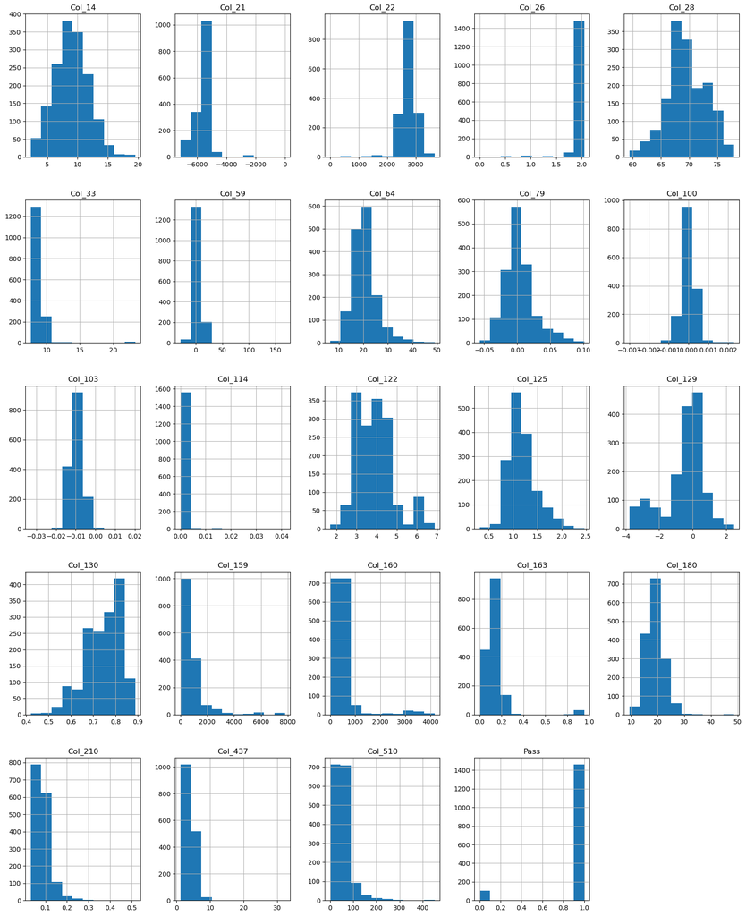

```python
df.hist(figsize=(20,25));
```

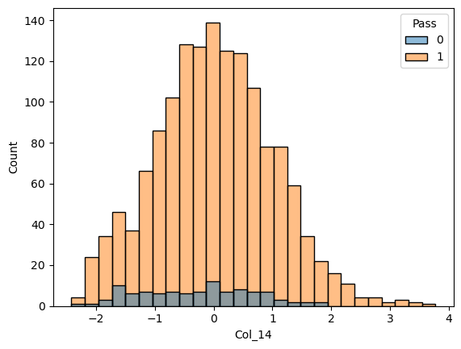

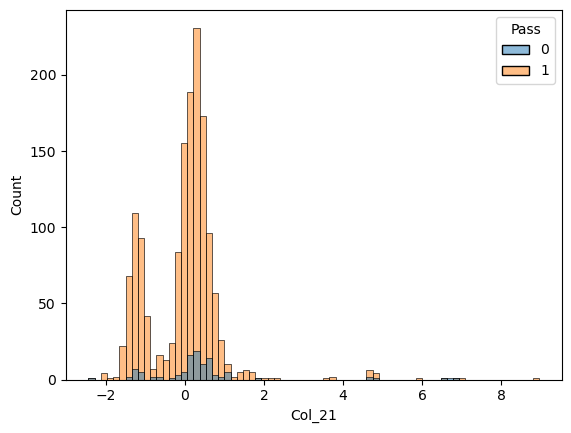

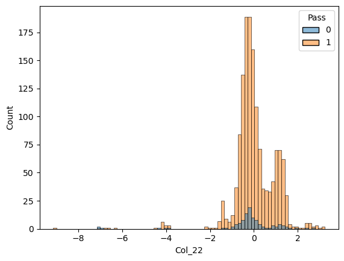

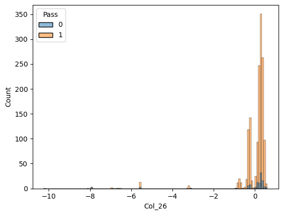

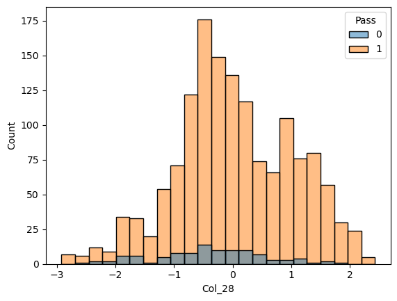

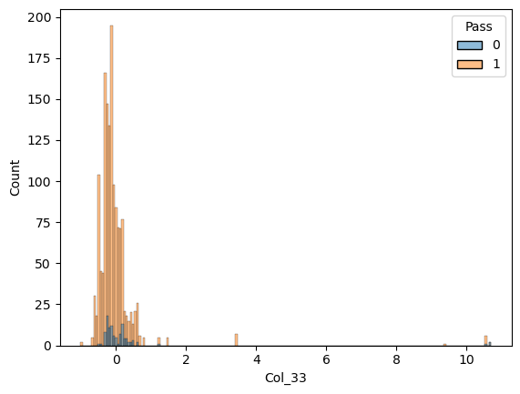

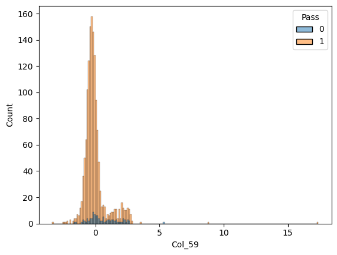

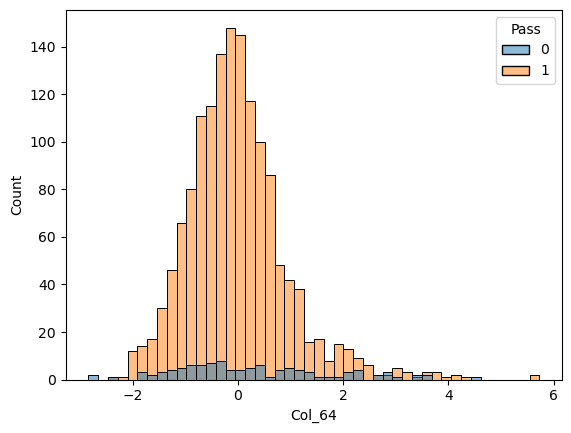

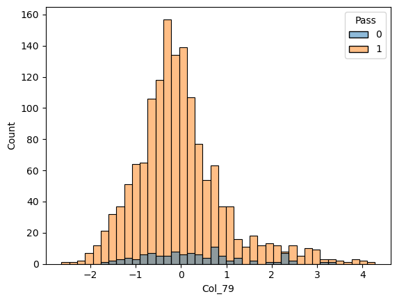

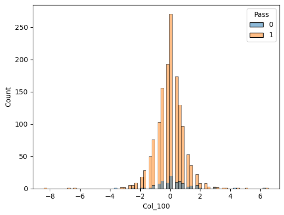

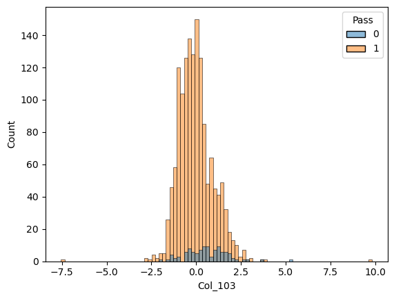

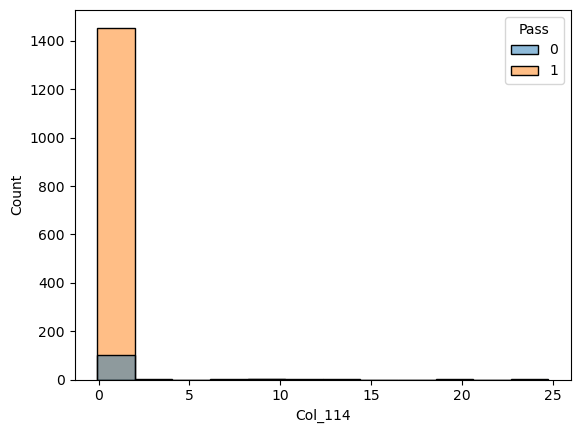

[12 more figures not shown]

```python
for x in df.columns:
  sns.histplot(data=df_scaled, x=x, hue="Pass")
  plt.show()
```

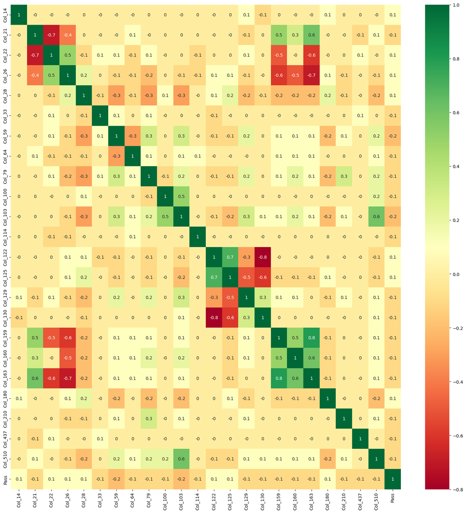

```python
plt.subplots(figsize=(20,20))
sns.heatmap(round(df_scaled.corr(),1), annot=True, cmap = 'RdYlGn')
plt.show()
```

```python
correlated_columns = fetch_correlated_columns(df_scaled, 0.6)
```

```
['Col_22', 'Col_125', 'Col_130', 'Col_163', 'Col_510']
```

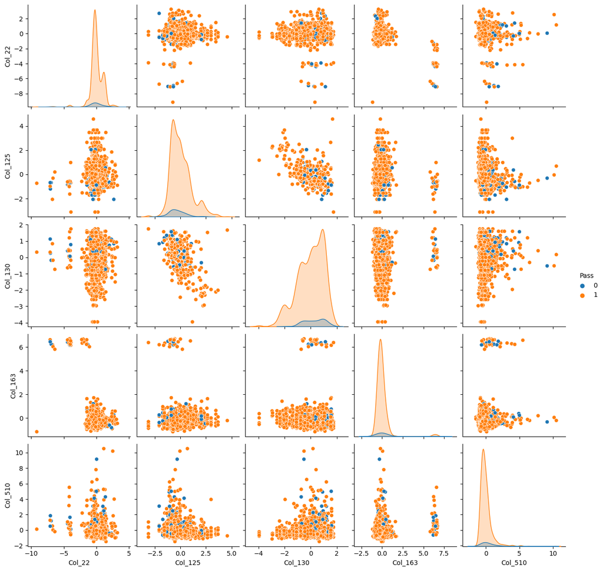

```python
sns.pairplot(df_scaled[['Col_22', 'Col_125', 'Col_130', 'Col_163', 'Col_510', 'Pass']], diag_kind='kde', hue='Pass');
```

# **4. Data pre-processing**

## **A. Segregate predictors vs target attributes.**

```python
X = df.iloc[:,:-1]
y = df.iloc[:,-1]
explore_data(X)
```

```
 The Shape of Dataset: (1567, 23) ; Number of Rows in the Dataset: 1567 ; Number of Columns in the Dataset: 23

  The Columns of the Dataset are: Index(['Col_14', 'Col_21', 'Col_22', 'Col_26', 'Col_28', 'Col_33', 'Col_59',
       'Col_64', 'Col_79', 'Col_100', 'Col_103', 'Col_114', 'Col_122',
       'Col_125', 'Col_129', 'Col_130', 'Col_159', 'Col_160', 'Col_163',
       'Col_180', 'Col_210', 'Col_437', 'Col_510'],
      dtype='object')

 The Features of the Dataset are:
 Col_14     float64
Col_21     float64
Col_22     float64
Col_26     float64
Col_28     float64
Col_33     float64
Col_59     float64
Col_64     float64
Col_79     float64
Col_100    float64
Col_103    float64
Col_114    float64
Col_122    float64
Col_125    float64
Col_129    float64
Col_130    float64
Col_159    float64
Col_160    float64
Col_163    float64
Col_180    float64
Col_210    float64
Col_437    float64
Col_510    float64
dtype: object

 The Non-Categorical Features of the Dataset are: ['Col_14' 'Col_21' 'Col_22' 'Col_26' 'Col_28' 'Col_33' 'Col_59' 'Col_64'
 'Col_79' 'Col_100' 'Col_103' 'Col_114' 'Col_122' 'Col_125' 'Col_129'
 'Col_130' 'Col_159' 'Col_160' 'Col_163' 'Col_180' 'Col_210' 'Col_437'
 'Col_510']

 The Categorical Features of the Dataset are:[]
```

## **B. Check for target balancing and fix it if found imbalanced.**

## **C. Perform train-test split and standardise the data or vice versa if required.**

Observation:

- Question B asks for target imbalance and fixing it
- Question C asks to train - test split & standardising the data

However, we do not balance the entire data. We only balance target data to train a high performance model. Our model has to perform better with the unseen data which may or may not be imbalanced.

If there is any imbalance in the target data we only fix it for train data and not for test data

```python
y.value_counts()
```

```
1    1463
0     104
Name: Pass, dtype: int64
```

```python
X_train, X_test, y_train, y_test = split_sampling(X, y)
```

```
X_train shape (1175, 23)

y_train shape (1175,)

X_test shape (392, 23)

y_test shape (392,)

--------------------------- AFTER SAMPLING ---------------------------------
X_train shape (2194, 23)

y_train shape (2194,)
```

```python
sc = StandardScaler()
sc.fit(X_train)
X_train = sc.transform(X_train)
X_test = sc.transform(X_test)
print(X_train.shape)
print(X_test.shape)
```

```
(2194, 23)
(392, 23)
```

```python
y_test.value_counts()
```

```
1    366
0     26
Name: Pass, dtype: int64
```

```python
y_train.value_counts()
```

```
1    1097
0    1097
Name: Pass, dtype: int64
```

## **D. Check if the train and test data have similar statistical characteristics when compared with original data.**

```python
X_train_df = pd.DataFrame(X_train)
X_test_df = pd.DataFrame(X_test)

X_train_stats= X_train_df.describe()[1:].T
X_train_stats["skew"]=X_train_df.skew()
X_train_stats["kurt"]=X_train_df.kurt()
```

```python
X_test_stats=X_test_df.describe()[1:].T
X_test_stats["skew"]=X_test_df.skew()
X_test_stats["kurt"]=X_test_df.kurt()
X_train_stats.head()
```

|  | mean | std | min | 25% | 50% | 75% | max | skew | kurt |
| --- | --- | --- | --- | --- | --- | --- | --- | --- | --- |
| 0 | 1.250899e-16 | 1.000228 | -2.467231 | -0.752070 | 0.010868 | 0.682810 | 4.100990 | 0.206580 | -0.084431 |
| 1 | -9.746078e-17 | 1.000228 | -2.029846 | -0.301576 | 0.036056 | 0.244564 | 6.862084 | 2.742195 | 11.710235 |
| 2 | -1.497840e-17 | 1.000228 | -6.936809 | -0.237967 | -0.015804 | 0.398403 | 2.563819 | -2.792991 | 12.769635 |
| 3 | 1.839724e-16 | 1.000228 | -7.177260 | -0.038247 | 0.286759 | 0.340481 | 0.501676 | -4.361728 | 18.884819 |
| 4 | 4.191585e-15 | 1.000228 | -2.930567 | -0.633317 | -0.078333 | 0.630766 | 2.659633 | 0.081228 | -0.133223 |

```python
X_test_stats.head()
```

|  | mean | std | min | 25% | 50% | 75% | max | skew | kurt |
| --- | --- | --- | --- | --- | --- | --- | --- | --- | --- |
| 0 | 0.026543 | 1.049569 | -2.214598 | -0.710602 | -0.054595 | 0.744598 | 3.567207 | 0.222833 | -0.135388 |
| 1 | -0.119280 | 0.804574 | -2.027048 | -0.448630 | 0.001236 | 0.199976 | 4.993290 | 2.065243 | 10.968540 |
| 2 | 0.041692 | 0.766644 | -5.360841 | -0.246418 | -0.033344 | 0.354152 | 2.092198 | -2.315118 | 13.404525 |
| 3 | 0.087284 | 0.740418 | -5.535881 | -0.046015 | 0.283727 | 0.353433 | 0.536623 | -5.417379 | 31.895076 |
| 4 | 0.211893 | 1.128145 | -2.750566 | -0.453040 | 0.139722 | 1.096801 | 2.832718 | -0.074870 | -0.352073 |

```python
y_stats=pd.DataFrame(index=["Train","Test"],columns=["0 Count","1 Count"," Ratio -1:1"])
stat=y_train.value_counts()

y_stats.iloc[0]=[stat.loc[0],stat.loc[1],stat.loc[0]/stat.loc[1]]
stat=y_test.value_counts()

y_stats.iloc[1]=[stat.loc[0],stat.loc[1],stat.loc[0]/stat.loc[1]]
y_stats
```

|  | 0 Count | 1 Count | Ratio -1:1 |
| --- | --- | --- | --- |
| Train | 1097 | 1097 | 1.0 |
| Test | 26 | 366 | 0.071038 |

Observations:

- X_train and X_test has similar skew
- Balancing of target is for training data and the test data remains same as we want to model to work with unseen data.

# **5. Model training, testing and tuning**

## **A. Use any Supervised Learning technique to train a model.**

## **E. Display and explain the classification report in detail.**

```python
%%time
from sklearn import metrics
lr = LogisticRegression(solver="liblinear")
lr.fit(X_train, y_train)
y_predict = lr.predict(X_test)

print('Accuracy of the train data :',lr.score(X_train, y_train))
print('Accuracy of the test data :',lr.score(X_test, y_test))
```

```
Accuracy of the train data : 0.7711941659070192
Accuracy of the test data : 0.7423469387755102
Wall time: 6 ms
```

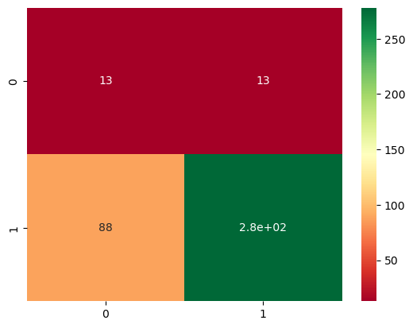

```python
confusion_matrix = metrics.confusion_matrix(y_test,y_predict)
df_confusion_matrix = pd.DataFrame(confusion_matrix)
sns.heatmap(df_confusion_matrix,annot=True, cmap = 'RdYlGn')
```

Observations:

```python
print('\n Classification report:')
print(metrics.classification_report(y_test,y_predict,digits=2))
```

```
 Classification report:
              precision    recall  f1-score   support

           0       0.13      0.50      0.20        26
           1       0.96      0.76      0.85       366

    accuracy                           0.74       392
   macro avg       0.54      0.63      0.53       392
weighted avg       0.90      0.74      0.80       392
```

## **B. Use cross validation techniques.**

```python
%%time

from sklearn.model_selection import KFold, StratifiedKFold, ShuffleSplit, LeaveOneOut
from sklearn.model_selection import cross_val_score

kfold = KFold(n_splits = 10)
shuffle_split = ShuffleSplit(n_splits=10, test_size=0.25, random_state= 42)
stratified_k_fold = StratifiedKFold(n_splits=10)
leave_one_out = LeaveOneOut()

model = LogisticRegression()

results= cross_val_score(estimator=model, X = X_train, y= y_train, cv = kfold)
print(f"Accuracy on KFold CV --> Minimum : {round(results.min()*100.0,2)}% ; Maximum : {round(results.max()*100.0,2)}% ; Mean : {round(results.mean()*100.0,2)}% and Standard Devation {round(results.std()*100.0,2)}%")


results= cross_val_score(estimator=model, X = X_train, y= y_train, cv = shuffle_split)
print(f"Accuracy on Shuffle Split CV --> Minimum : {round(results.min()*100.0,2)}% ; Maximum : {round(results.max()*100.0,2)}% ; Mean : {round(results.mean()*100.0,2)}% and Standard Devation{round(results.std()*100.0,2)}%")


results = cross_val_score(estimator=model, X = X_train, y= y_train, cv = stratified_k_fold)
print(f"Accuracy on Stratified KFold CV --> Minimum : {round(results.min()*100.0,2)}% ; Maximum : {round(results.max()*100.0,2)}% ; Mean : {round(results.mean()*100.0,2)}% and Standard Devation {round(results.std()*100.0,2)}%")


results = cross_val_score(estimator=model, X = X_train, y= y_train, cv = leave_one_out)
print(f"Accuracy on Leave one out CV -->  Minimum : {round(results.min()*100.0,2)}% ; Maximum : {round(results.max()*100.0,2)}% ; Mean : {round(results.mean()*100.0,2)}% and Standard Devation {round(results.std()*100.0,2)}%")


model.fit(X_train,y_train)
print(f"Accuracy on KFold CV --> Minimum : {round(results.min()*100.0,2)}% ; Maximum : {round(results.max()*100.0,2)}% ; Mean : {round(results.mean()*100.0,2)}% and Standard Devation {round(results.std()*100.0,2)}%")
```

```
Accuracy on KFold CV --> Minimum : 65.75% ; Maximum : 79.0% ; Mean : 73.88% and Standard Devation 4.06%
Accuracy on Shuffle Split CV --> Minimum : 73.95% ; Maximum : 79.78% ; Mean : 77.4% and Standard Devation1.89%
Accuracy on Stratified KFold CV --> Minimum : 73.18% ; Maximum : 79.91% ; Mean : 76.85% and Standard Devation 1.93%
Accuracy on Leave one out CV -->  Minimum : 0.0% ; Maximum : 100.0% ; Mean : 76.44% and Standard Devation 42.44%
Accuracy on KFold CV --> Minimum : 0.0% ; Maximum : 100.0% ; Mean : 76.44% and Standard Devation 42.44%
Wall time: 15.2 s
```

## **C. Apply hyper-parameter tuning techniques to get the best accuracy.**

```python
from sklearn.pipeline import Pipeline
logistic_pipeline = Pipeline([('scl',StandardScaler()),('LR' , LogisticRegression())])
param_grid_logistic = {  'LR__penalty' : ['l1', 'l2'],
                         'LR__C' : np.logspace(-4, 4, 20),
                         'LR__solver' : ['liblinear']}

clf_lr = GridSearchCV(logistic_pipeline, param_grid = param_grid_logistic, cv = 5, verbose=3, n_jobs=-1)
best_clf_lr = clf_lr.fit(X_train, y_train)
```

```
Fitting 5 folds for each of 40 candidates, totalling 200 fits
```

```python
print(" The best cross-validation accuracy: {:.2f}". format( clf_lr.best_score_))
print(" The best parameters: ", clf_lr.best_params_)
print(" The test set accuracy: {:.2f}". format( clf_lr.score( X_test, y_test)))
```

```
 The best cross-validation accuracy: 0.77
 The best parameters:  {'LR__C': 0.03359818286283781, 'LR__penalty': 'l2', 'LR__solver': 'liblinear'}
 The test set accuracy: 0.75
```

## **D. Use any other technique/method which can enhance the model performance.**

```python
from sklearn.decomposition import PCA

covarince_matrix = np.cov(X,rowvar = False)
pca = PCA(n_components=10)
pca.fit(X)
print(pca.explained_variance_)
print(pca.explained_variance_ratio_)
```

```
[1.26410558e+06 2.77899380e+05 2.05696281e+05 2.70789679e+04
 1.38120496e+03 8.98123144e+01 2.09831294e+01 1.09285448e+01
 8.65109383e+00 7.65759521e+00]
[7.11648554e-01 1.56447922e-01 1.15800027e-01 1.52445402e-02
 7.77571530e-04 5.05612859e-05 1.18127899e-05 6.15239997e-06
 4.87027232e-06 4.31096630e-06]
```

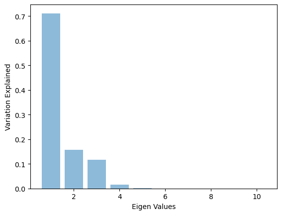

```python
plt.bar(list(range(1,11)), pca.explained_variance_ratio_, alpha = 0.5, align = 'center')
plt.ylabel('Variation Explained')
plt.xlabel('Eigen Values')
plt.show()
```

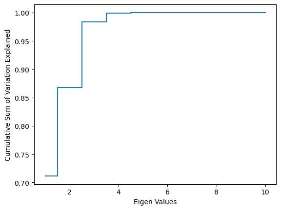

```python
plt.step(list(range(1,11)), np.cumsum(pca.explained_variance_ratio_), where = 'mid')
plt.ylabel('Cumulative Sum of Variation Explained')
plt.xlabel('Eigen Values')
plt.show()
```

```python
np.round(np.cumsum(pca.explained_variance_ratio_),3)
```

```
array([0.712, 0.868, 0.984, 0.999, 1.   , 1.   , 1.   , 1.   , 1.   ,
       1.   ])
```

```python
pca_new_train = pca.transform(X_train)
pca_new_test = pca.transform(X_test)
model_pca = LogisticRegression()
model_pca.fit(pca_new_train,y_train)
print(f'The test accuracy of Logistic Regression model after implementation of PCA is {round(100*model_pca.score(pca_new_test,y_test),2)}%')
```

```
The test accuracy of Logistic Regression model after implementation of PCA is 78.57%
```

Observations:

## **F. Apply the above steps for all possible models that you have learnt so far.**

## **6 A. Display and compare all the models designed with their train and test accuracies.**

```
 Models are initiated
Processing  Decision Tree
Classification accuracy of the train data : 1.0
Classification accuracy of the test data : 0.8239795918367347
```

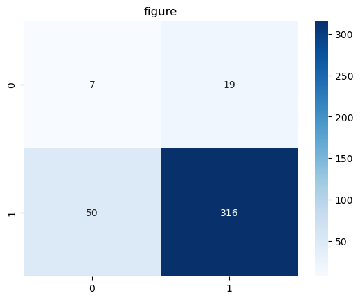

[output not shown]

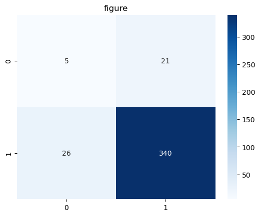

[output not shown]

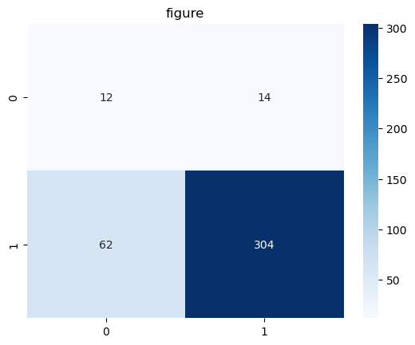

[output not shown]

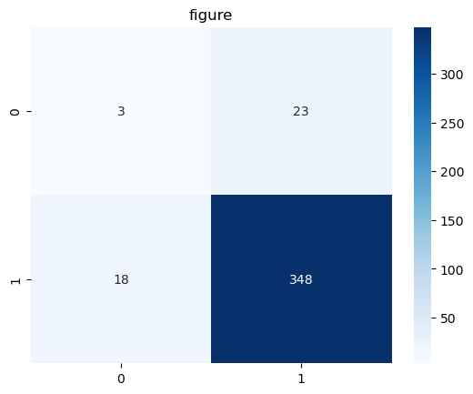

[output not shown]

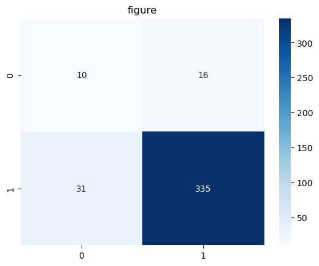

[output not shown]

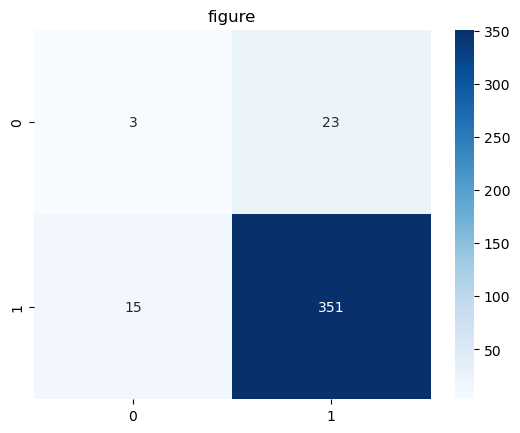

[output not shown]

```python
%%time
result_df = modelling(X_train, X_test, y_train, y_test)
result_df.to_csv('result_df.csv')
```

```python
result_df.head()
```

| Model | R Squared | MSE | MSLE | Accuracy | R2 CV | RMSE CV | RMSLE CV | Accuracy CV | Elapsed |
| --- | --- | --- | --- | --- | --- | --- | --- | --- | --- |
| Decision Tree | -1.842371 | 0.419548 | 0.290808 | 0.82398 | 0.593436 | 0.317129 | 0.219817 | 0.907733 | 0.480527 |
| Bagging Ensemble | -0.936108 | 0.346263 | 0.240011 | 0.880102 | 0.793987 | 0.224628 | 0.1557 | 0.938138 | 9.615888 |
| Ada Boost Ensemble | -2.130727 | 0.440315 | 0.305203 | 0.806122 | 0.462193 | 0.363684 | 0.252087 | 0.897843 | 2.14786 |
| Random Forest | -0.688945 | 0.323407 | 0.224168 | 0.895408 | 0.879691 | 0.17086 | 0.118431 | 0.94626 | 4.062974 |
| Gradient Boost Ensemble | -0.936108 | 0.346263 | 0.240011 | 0.880102 | 0.728382 | 0.257966 | 0.178809 | 0.938138 | 7.721794 |

## **B. Select the final best trained model along with your detailed comments for selecting this model.**

```python
%%time
model = best_model(X_train, y_train) # note: this will find the best model
print(f' best model --> ')
print(model)
```

```
finding best params for Extreme Gradient Boost Ensemble
Fitting 5 folds for each of 54 candidates, totalling 270 fits
clf -> GridSearchCV(estimator=XGBClassifier(base_score=None, booster=None,
                                     colsample_bylevel=None,
                                     colsample_bynode=None,
                                     colsample_bytree=None,
                                     enable_categorical=False,
                                     eval_metric='mlogloss', gamma=None,
                                     gpu_id=None, importance_type=None,
                                     interaction_constraints=None,
                                     learning_rate=None, max_delta_step=None,
                                     max_depth=None, min_child_weight=None,
                                     missing=nan, monotone...
                                     num_parallel_tree=None, predictor=None,
                                     random_state=None, reg_alpha=None,
                                     reg_lambda=None, scale_pos_weight=None,
                                     seed=20, subsample=None, tree_method=None,
                                     validate_parameters=None, verbosity=None),
             param_grid={'colsample_bytree': [0.3, 0.7],
                         'learning_rate': [0.01, 0.05, 0.1],
                         'max_depth': [3, 6, 10],
                         'n_estimators': [100, 500, 1000]},
             scoring='neg_mean_squared_error', verbose=1)
Best parameters: {'colsample_bytree': 0.3, 'learning_rate': 0.05, 'max_depth': 10, 'n_estimators': 500}
Lowest RMSE:  0.16398070758549826
 best model -->
XGBClassifier(base_score=None, booster=None, colsample_bylevel=None,
              colsample_bynode=None, colsample_bytree=0.3,
              enable_categorical=False, eval_metric='mlogloss', gamma=None,
              gpu_id=None, importance_type=None, interaction_constraints=None,
              learning_rate=0.05, max_delta_step=None, max_depth=10,
              min_child_weight=None, missing=nan, monotone_constraints=None,
              n_estimators=500, n_jobs=None, num_parallel_tree=None,
              predictor=None, random_state=None, reg_alpha=None,
              reg_lambda=None, scale_pos_weight=None, seed=20, subsample=None,
              tree_method=None, validate_parameters=None, verbosity=None)
Wall time: 3min 3s
```

Observation:

- we choose XGBoostClassifier as best model as it has lowest RMSE value.

## **C. Pickle the selected model for future use.**

```python
%%time
store_model(model)
```

```
model stored successfully...!
Wall time: 1 ms
```